# Capstone - Simulated Cash Flow Analysis

Author

Brandon Dahl

## Revenue

Below are Regenerons historical revenue statitistics as well as 10-year forecasts of revenue taken from a consensus of analysts.

### Revenue Historical & Forecast

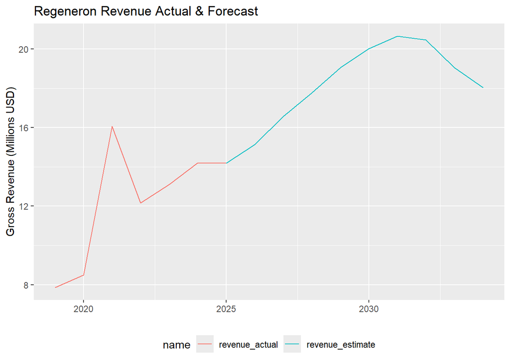

### Revenue By Region

The revenue by region statistics will allow us to calculate how much of future forecast revenue will be exposed to international exchange rates.

Unfortunately, we’re missing revenue breakdown by country, as well as cost breakdown by country, so we won’t be able to pinpoint Regeneron’s net foreign exchange exposure.

Regeneron - Revenue By Region

| Year | Gross Revenue US | Gross Revenue International | Percentages US | Percentages International |
| --- | --- | --- | --- | --- |
| 2019 | 5,248 | 2,616 | 66.74% | 33.26% |
| 2020 | 6,125 | 2,372 | 72.08% | 27.92% |
| 2021 | 12,398 | 3,673 | 77.14% | 22.86% |
| 2022 | 7,186 | 4,987 | 59.03% | 40.97% |
| 2023 | 7,295 | 5,822 | 55.61% | 44.39% |
| 2024 | 7,741 | 6,461 | 54.50% | 45.50% |

## Analyze Cash Flow Impacts

Regeneron has noted the following in their 2024 10K:

*Our revenue from outside the United States will increase as our products, whether marketed or otherwise commercialized by us or our collaborators, gainmarketing approval in such jurisdictions. Our primary foreign currency exposure relates to movements in the Japanese yen, euro, British pound sterling,Canadian dollar, Chinese yuan, and Australian dollar.*

Source: Form 10K, Other Risk Related To Our Business

As such, we’ll analyze the impacts to forecast future cash flows based upon exposure to the following currencies. As noted previously, we don’t have the actual data on how much exposure Regeneron has to each currency. Accordingly, our analysis will assume that the vast majority of the revenue is concentrated in Western countries.

Foreign Currencies

| Currency | Symbol | Percentage |
| --- | --- | --- |
| Japanese Yen | JPY | 10% |
| Euro | EUR | 40% |
| British Pound | GBP | 20% |
| Canadian Dollar | CAD | 10% |
| Chinese Yuan | CYN | 10% |
| Australian Dollar | AUD | 10% |

```r
# Set Cash Flow Percentages
cash_percentages <- data.frame('rev_pct_aud' = 1/10,
                               'rev_pct_cad' = 1/10,
                               'rev_pct_cny' = 1/10,
                               'rev_pct_eur' = 4/10,
                               'rev_pct_gbp' = 2/10,
                               'rev_pct_jpy' = 1/10)

# Get International Revenue
int_revenue <- subset(hist_revenue_region_clean, date == 2024, select = row_pct) |> pull()
```

```r
# Setup Cash Flow Calculations
cash_flow_setup <- ex_paths |>
  janitor::clean_names() |>
  # Update Names
  {\(.)
      rename_with(., ~ paste0('simulated_rate_', .x, recycle0 = TRUE), !contains(c('days','sim')))}() |>
  # Add Current Exchange Rate
  cross_join(x = _ , y = current_exchange_rates |>
              pivot_wider(names_from = country,
                          values_from = exchange_rate,
                          names_prefix = 'exchange_rate_current_') |>
               janitor::clean_names()) |>
  # Add Country Revenue Percentage
  cross_join(x = _, y = cash_percentages) |>
  # Add Forecast Company Revenue
  mutate(forecast_gross_revenue_int = (subset(growth_estimates_clean, year == 2025, select = revenue_estimate) |>
                                         pull())*1000*int_revenue) |>
  group_by(sim) |>
  # Calculate Country Revenue Total (USD)
  mutate(rev_current_aud = forecast_gross_revenue_int*rev_pct_aud,
         rev_current_cad = forecast_gross_revenue_int*rev_pct_cad,
         rev_current_cny = forecast_gross_revenue_int*rev_pct_cny,
         rev_current_eur = forecast_gross_revenue_int*rev_pct_eur,
         rev_current_gbp = forecast_gross_revenue_int*rev_pct_gbp,
         rev_current_jpy = forecast_gross_revenue_int*rev_pct_jpy) |>
  # Calculate Daily Country Revenue (USD)
  mutate(rev_current_daily_aud = rev_current_aud/252,
         rev_current_daily_cad = rev_current_cad/252,
         rev_current_daily_cny = rev_current_cny/252,
         rev_current_daily_eur = rev_current_eur/252,
         rev_current_daily_gbp = rev_current_gbp/252,
         rev_current_daily_jpy = rev_current_jpy/252) |>
  # Calculate Daily Revenue Converted
  mutate(rev_current_daily_sim_aud = (rev_current_daily_aud*exchange_rate_current_aud)/mean(simulated_rate_aud),
         rev_current_daily_sim_cad = (rev_current_daily_cad*exchange_rate_current_cad)/mean(simulated_rate_cad),
         rev_current_daily_sim_cny = (rev_current_daily_cny*exchange_rate_current_cny)/mean(simulated_rate_cny),
         rev_current_daily_sim_eur = (rev_current_daily_eur*exchange_rate_current_eur)/mean(simulated_rate_eur),
         rev_current_daily_sim_gbp = (rev_current_daily_gbp*exchange_rate_current_gbp)/mean(simulated_rate_gbp),
         rev_current_daily_sim_jpy = (rev_current_daily_jpy*exchange_rate_current_jpy)/mean(simulated_rate_jpy)) |>
  # Calculate Total Cash
  mutate(rev_total_current = rev_current_daily_aud + rev_current_daily_cad +
           rev_current_daily_cny + rev_current_daily_eur +
           rev_current_daily_gbp + rev_current_daily_jpy,
         rev_total_current_sim = rev_current_daily_sim_aud + rev_current_daily_sim_cad +
           rev_current_daily_sim_cny + rev_current_daily_sim_eur +
           rev_current_daily_sim_gbp + rev_current_daily_sim_jpy) |>
  ungroup() |>
  # Reorder
  arrange(sim, days)
```

```r
# Create Long Data To Calculate Statistics
cash_flow_setup_long <- cash_flow_setup |>
  select(-c(rev_total_current, rev_total_current_sim)) |>
  pivot_longer(cols = !c('days','sim')) |>
  mutate(country = stringr::str_sub(str = name, start = -3, -1),
         name = stringr::str_replace(string = name, pattern = paste0('_',country), replacement = '')) |>
  select(days, sim, country, name, value) |>
  arrange(country, sim, days, name) |>
  pivot_wider(names_from = name, values_from = value) |>
  filter(country != 'int')

# Calculate Simulation Results
cash_flow_results_sim <- cash_flow_setup_long |>
  # Group By Currency and Simulation Number
  group_by(country, sim) |>
  # Calculate Grouped Statistics
  summarise(exchange_rate_current_mean = mean(exchange_rate_current, na.rm = TRUE),
            exchange_rate_simulated_mean = mean(simulated_rate, na.rm = TRUE),
            rev_current = mean(rev_current, na.rm = TRUE),
            rev_sim = sum(rev_current_daily_sim, na.rm = TRUE)) |>
  ungroup() |>
  arrange(country, sim)

# Calculate Currency Statistics
cash_flows_stats_currency <- cash_flow_results_sim |>
  # Calculate Higher/Lower Than Forecast
  mutate(higher_than_forecast = if_else(rev_sim > rev_current, 1, 0),
         lower_than_forecast = if_else(rev_sim < rev_current, 1, 0)) |>
  group_by(country) |>
  # Calculate Summary Currency Statistics
  summarise(n_sim = n(),
            # Exchange Rate Statistics
            exchange_rate_sim_mean = mean(exchange_rate_simulated_mean, na.rm = TRUE),
            exchange_rate_sim_max = max(exchange_rate_simulated_mean, na.rm = TRUE),
            exchange_rate_sim_min = min(exchange_rate_simulated_mean, na.rm = TRUE),
            exchange_rate_current = mean(exchange_rate_current_mean , na.rm = TRUE),
            # Cash Flow Statistics
            rev_sim_mean = mean(rev_sim, na.rm = TRUE),
            rev_sim_max = max(rev_sim, na.rm = TRUE),
            rev_sim_min = min(rev_sim, na.rm = TRUE),
            rev_sim_sd = sd(rev_sim, na.rm = TRUE),
            rev_sim_sd_pct = rev_sim_sd/rev_sim_mean,
            rev_current = mean(rev_current, na.rm = TRUE),
            # Higher/Lower Than Forecast
            higher_than_forecast = sum(higher_than_forecast, na.rm = TRUE),
            lower_than_forecast = sum(lower_than_forecast),
            higher_than_forecast_pct = higher_than_forecast/n_sim,
            lower_than_forecast_pct = lower_than_forecast/n_sim) |>
  ungroup()

# Calculate Simulation Statistics
cash_flow_stats_sim <- cash_flow_results_sim |>
  group_by(sim) |>
  summarise(rev_current = sum(rev_current, na.rm = TRUE),
            rev_sim = sum(rev_sim)) |>
  ungroup()

# Cash Flow Simulate Summary Stats
cash_flow_stats_sim_sum <- cash_flow_stats_sim |>
  summarise(rev_current = mean(rev_current, na.rm = TRUE),
            rev_sim_mean = mean(rev_sim, na.rm = TRUE),
            rev_sim_max = max(rev_sim, na.rm = TRUE),
            rev_sim_min = min(rev_sim, na.rm = TRUE),
            rev_sim_sd = sd(rev_sim, na.rm = TRUE),
            rev_sim_var = rev_sim_mean - quantile(rev_sim, probs = .05),
            rev_sim_var_pct = rev_sim_var/rev_current)
```

### Simulation Table

#### By Currency

Cash Flow Simulation Results

| Currency | N Simulation | Exchange Rate Mean | Exchange Rate Max | Exchange Rate Min | Exchange Rate Current | Total Revenue (USD Mean | Total Revenue (USD Max | Total Revenue (USD Min | Total Revenue (USD SD | Total Revenue (USD SD Pct | Total Revenue (USD Base Forecast | Comparison With Base Forecast Higher Than Forecast | Comparison With Base Forecast Lower Than Forecast | Comparison With Base Forecast Higher Than Forecast Pct | Comparison With Base Forecast Lower Than Forecast Pct |
| --- | --- | --- | --- | --- | --- | --- | --- | --- | --- | --- | --- | --- | --- | --- | --- |
| AUD | 500 | 1.58 | 1.98 | 1.30 | 1.54 | $633 | $764 | $503 | $43 | 6.76% | $646 | 183 | 317 | 36.60% | 63.40% |
| CAD | 500 | 1.39 | 1.63 | 1.20 | 1.37 | $640 | $736 | $544 | $31 | 4.80% | $646 | 215 | 285 | 43.00% | 57.00% |
| CNY | 500 | 7.30 | 7.61 | 7.01 | 7.19 | $636 | $662 | $610 | $10 | 1.50% | $646 | 75 | 425 | 15.00% | 85.00% |
| EUR | 500 | 0.88 | 1.02 | 0.75 | 0.88 | $2,598 | $3,037 | $2,230 | $128 | 4.93% | $2,582 | 283 | 217 | 56.60% | 43.40% |
| GBP | 500 | 0.75 | 0.86 | 0.63 | 0.74 | $1,271 | $1,503 | $1,103 | $65 | 5.10% | $1,291 | 183 | 317 | 36.60% | 63.40% |
| JPY | 500 | 142.89 | 171.55 | 119.27 | 142.58 | $646 | $772 | $537 | $35 | 5.35% | $646 | 246 | 254 | 49.20% | 50.80% |

#### By Simulation

Simulation Results

| Base Forecast Total Revenue | Simulated Forecast Mean | Simulated Forecast Max | Simulated Forecast Min | Simulated Forecast SD | Simulated VAR 95% VAR | Simulated VAR 95% VAR Pct |
| --- | --- | --- | --- | --- | --- | --- |
| $6,456 | $6,424 | $7,371 | $5,796 | $236 | $393 | 6.09% |

### Simulation Plots

#### By Currency

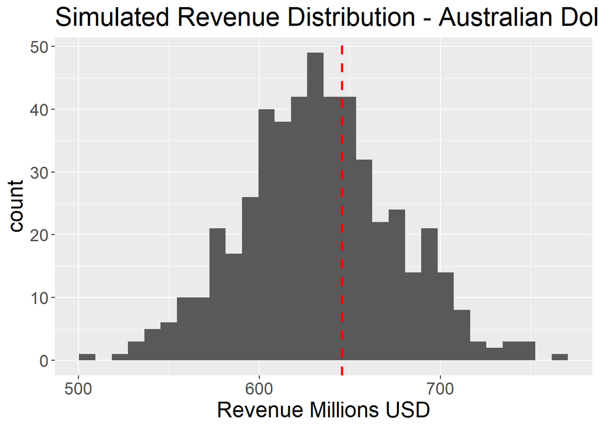

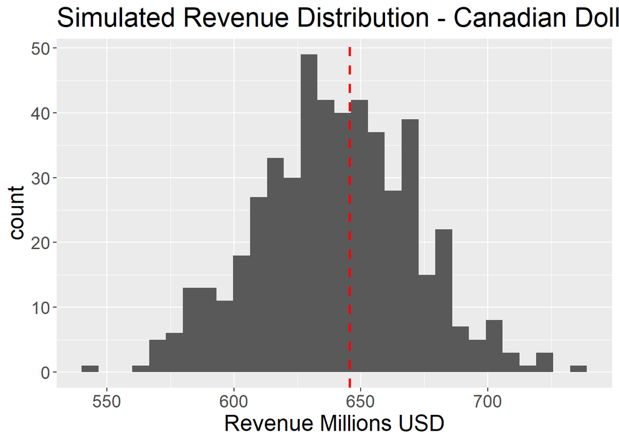

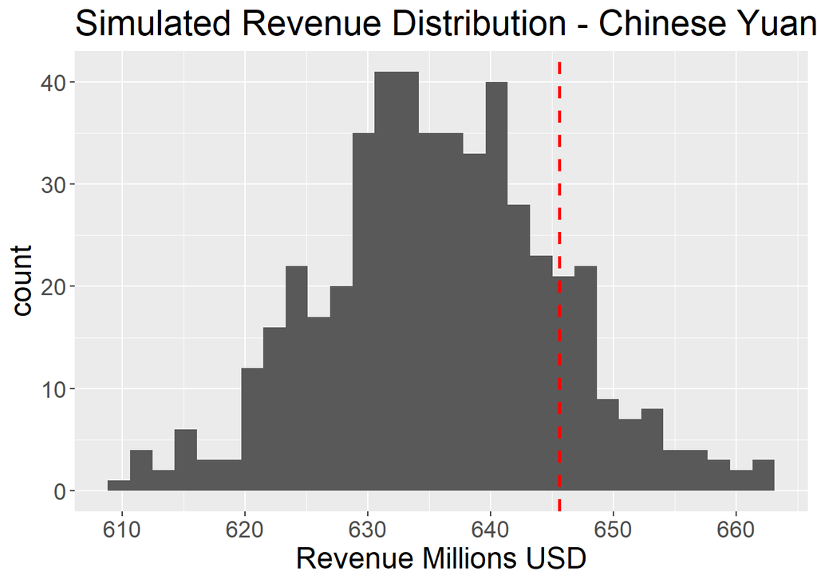

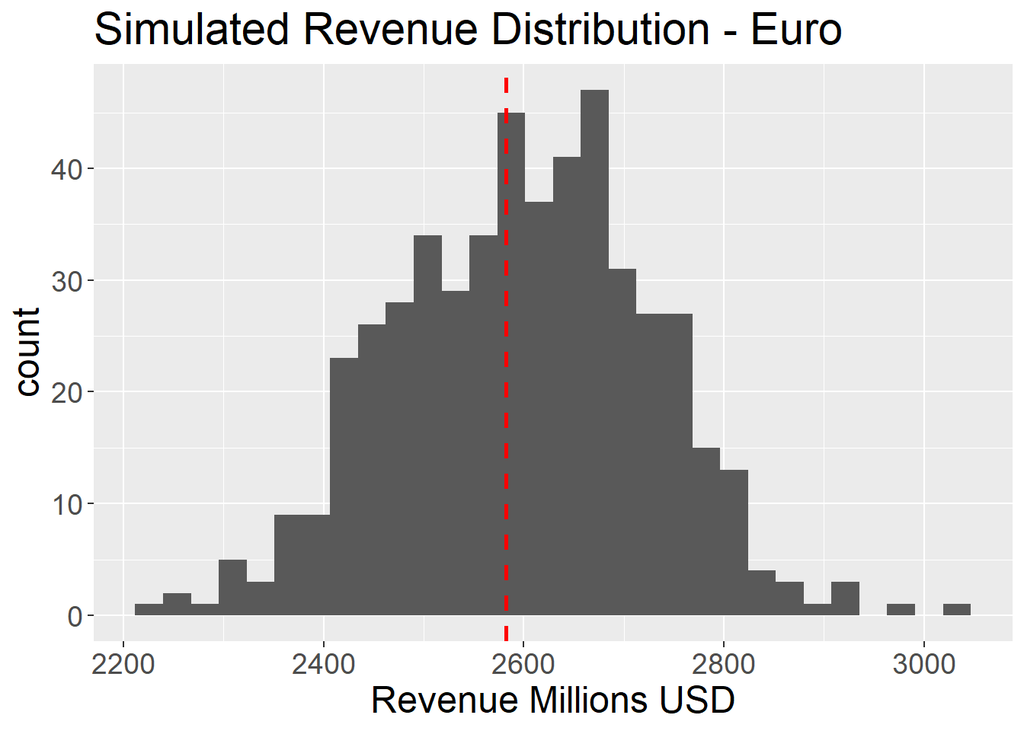

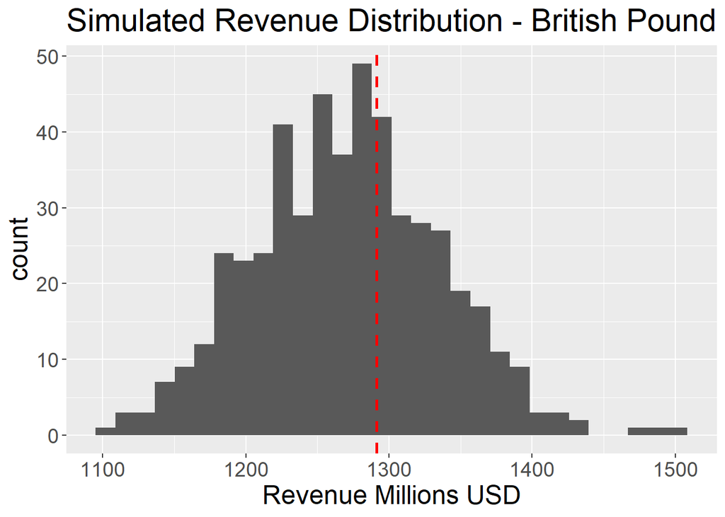

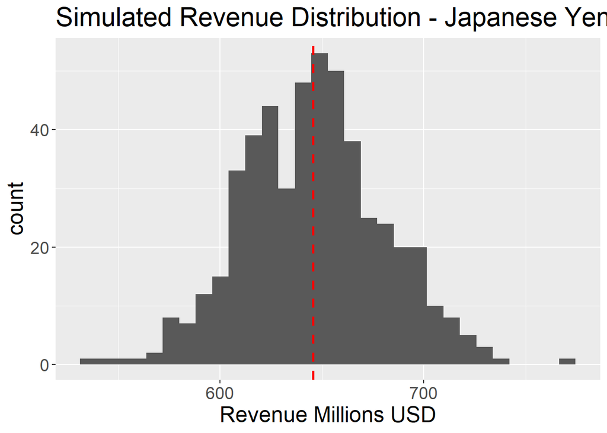

#### By Simulation

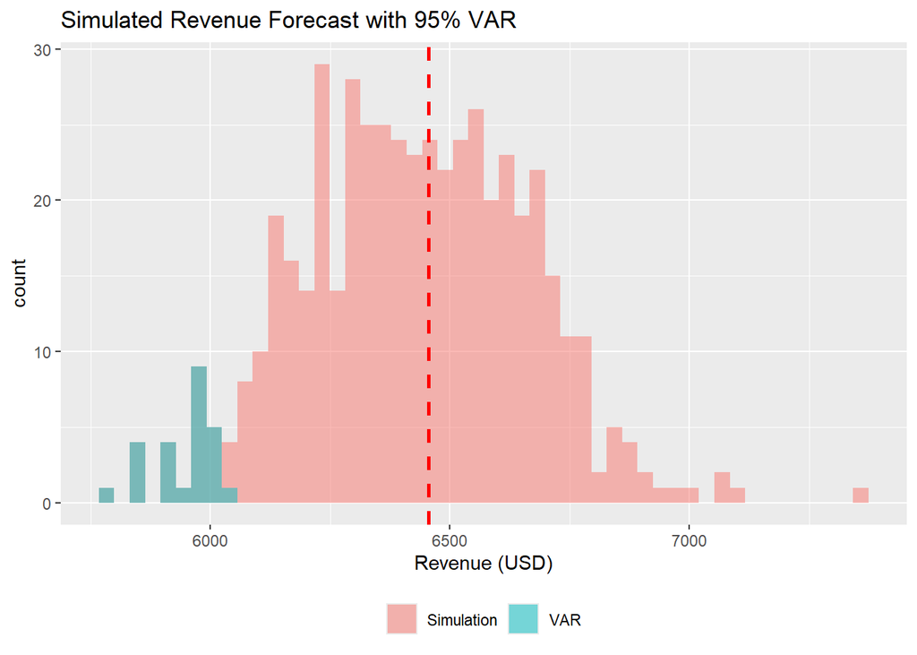

### Forecast Revenue

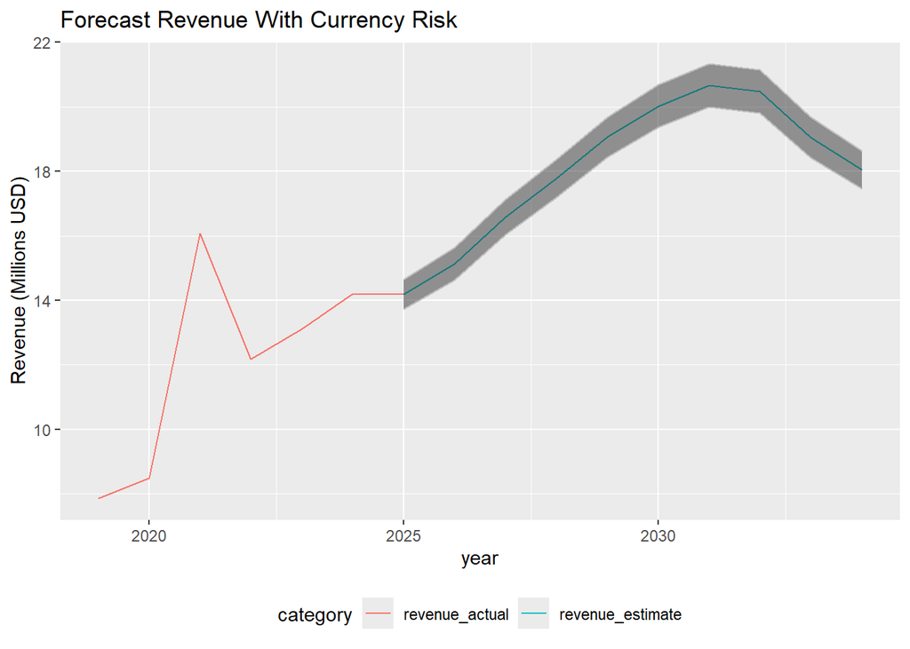